# Trends in the US Prison System

### Demographic Trends

The racial breakdown of the prison population between blacks and whites has stayed fairly even over time (implying over-representation of blacks due to their significantly smaller representation in the overall US population). Other minorities have increased their share of the prison population, in-line with an increased share of the overall population. The black prison population overtook the white prison population in the years between the 1984 and 1994 crime bills. This may have been due to the lowered tolerance of drug crimes, although we were unable to obtain the data necessary to investigate this possibility. From 1994 to 2010, this trend reversed.

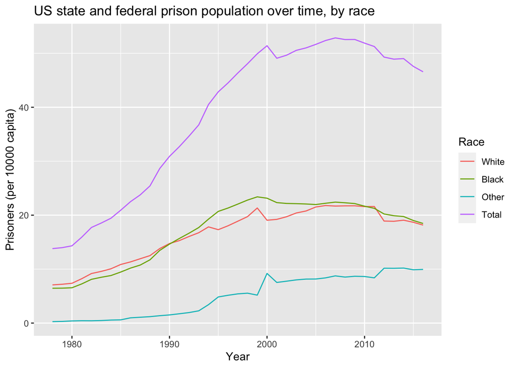

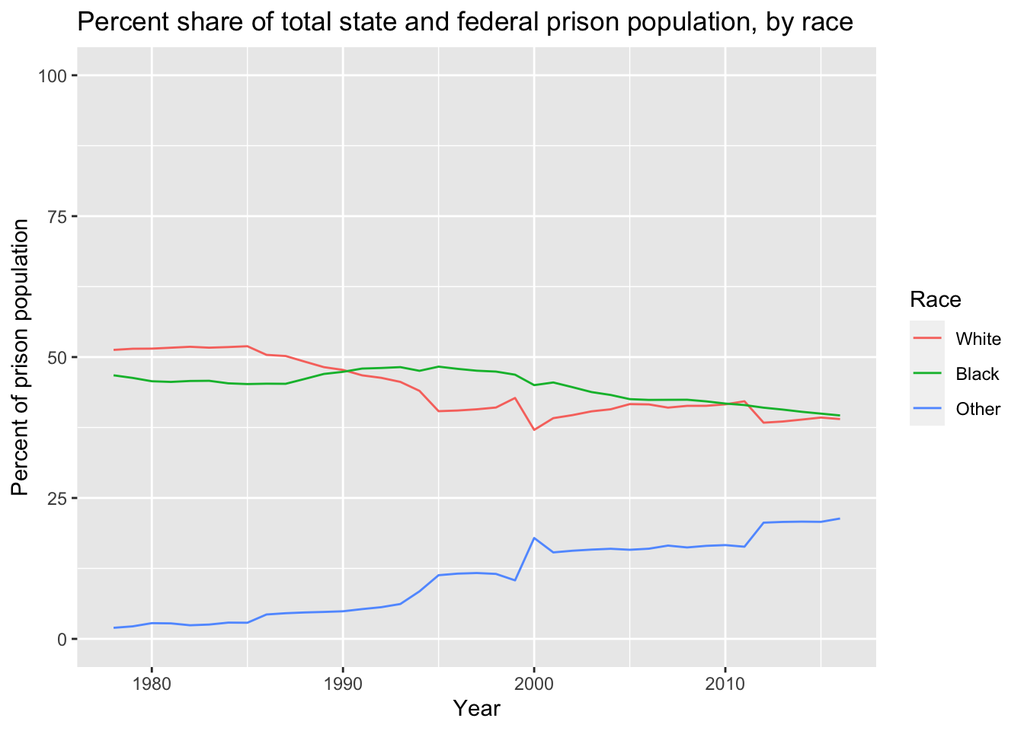

The sex breakout of the prison population remains overwhelmingly male, although their share of the population has decreased slightly over time.

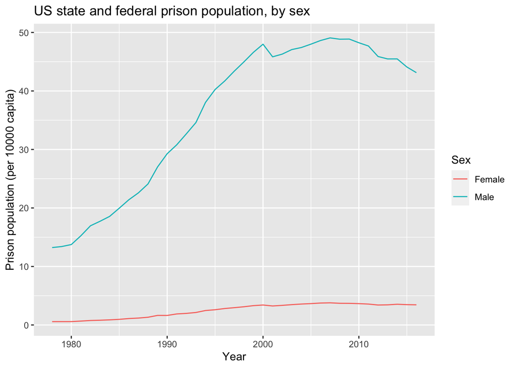

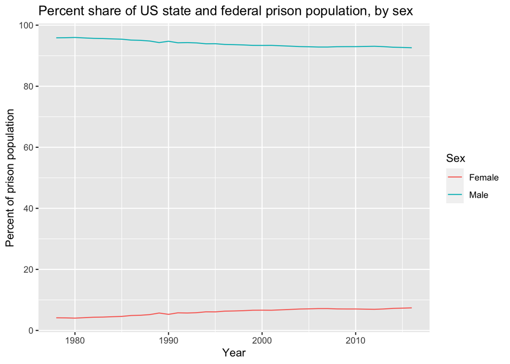

Aside from the noted subtle trends, race and sex do not alone significantly explain the drastic increases in the prison population.

### State Trends

Louisiana currently has the highest incarceration rate in the country, followed by Delaware, Oklahoma, Mississippi and Arizona.

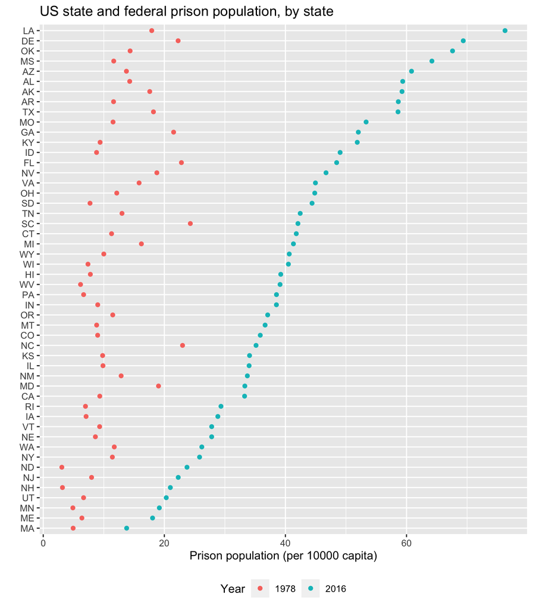

The primary driver of the increase in US incarceration rate is the south, with Louisiana, Oklahoma and Mississippi showing the largest increases in per-capita incarceration.

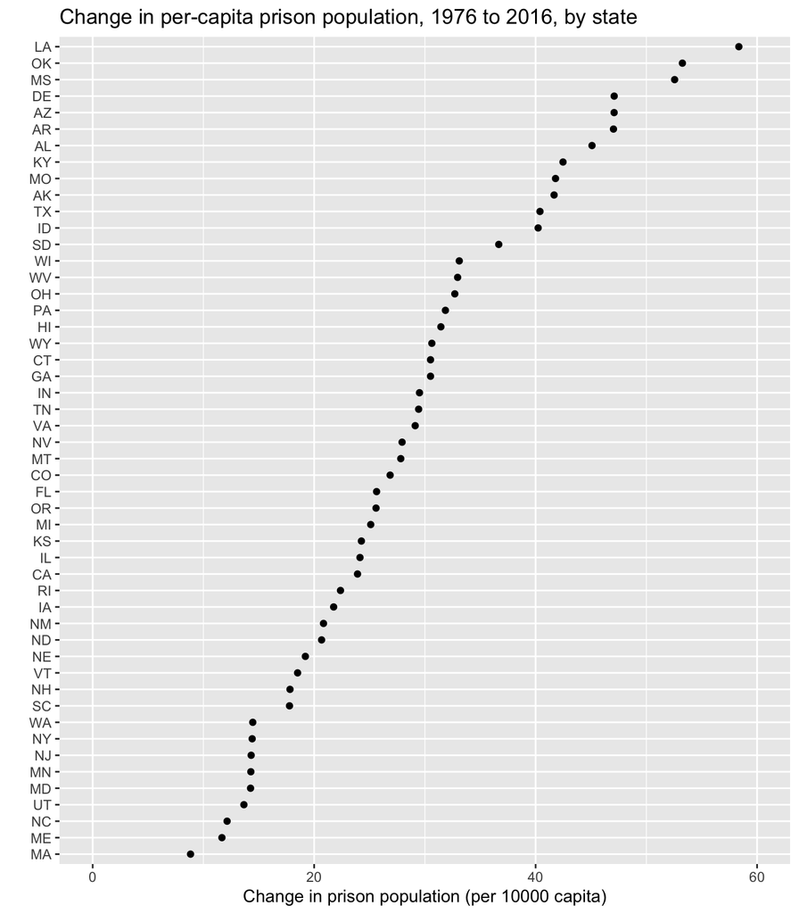

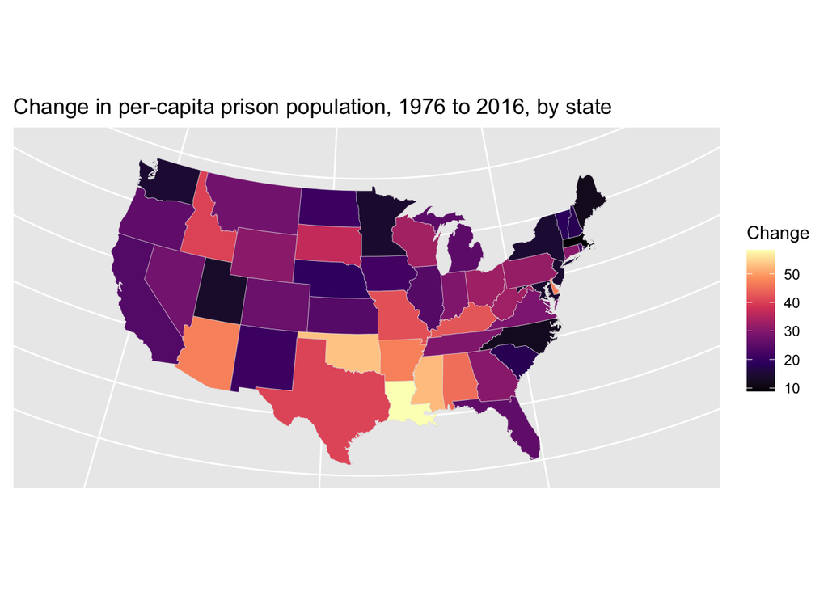

State dynamics appear to be a significant factor in the increase in prison population, given the major disparities in change of per-capita prison population over time. While all states have seen considerable increases in per-capita prison population, the south has shown a much larger growth than other regions.

### Vacancy Rates

One symptom of heightened incarceration rates is overcrowding in prisons. We can see in the below graph that many states, in 2016, had more prisoners under jurisdiction than their design-specified capacity. In fact some, states have approximately doubled the original intended capacity of their prisons. This leads to over-crowding of current prisons or increased funding of new public or private prisons.

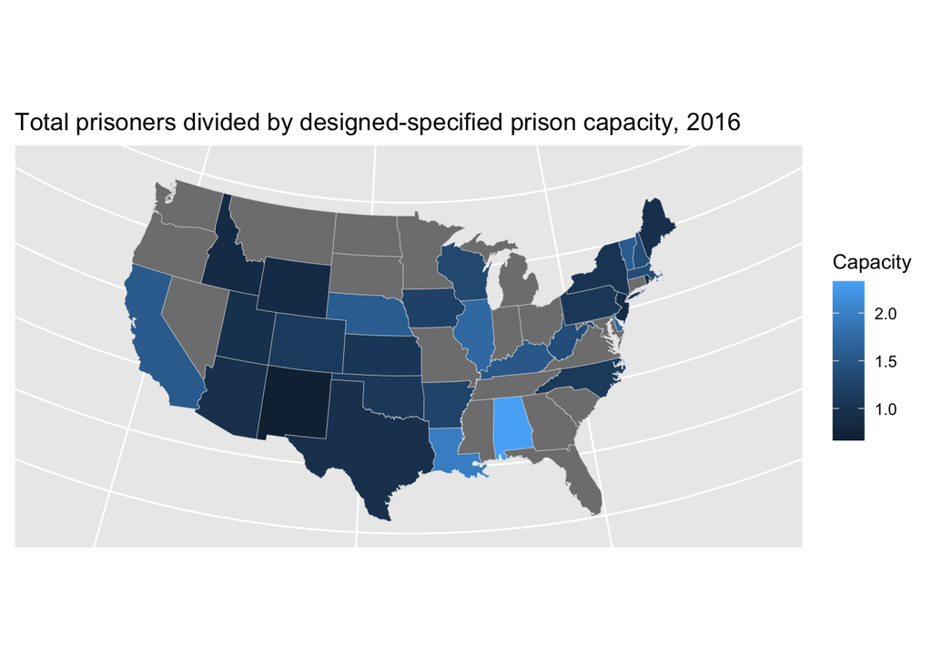

### Closing Remarks

It appears that the increases in prison population is driven both by by federal policies, such as the crime bills of 1984 and 1994, as well as state-specific policy. We expect to have seen a more even increase in per-capita prison populations across states if the primary driver was federal legislation, but the evidence is clear that this is not the case. However, since all states have seen increases in per-capita prison population, it appears that federal legislation plays a role. Regardless of cause, the evidence is clear that the prison system is currently bloated, demanding either more funding or fewer prisoners.

# Interactive Component

Please see our shiny app at `https://tianyaohan.shinyapps.io/shiny_map/`.

# Conclusion

We ran into a few limitations during the project that made things more difficult. First off, there is no clear-cut story for something as vast and nuanced as the US Prison System, beyond just saying that the size of the population has grown. Nonetheless, there are many interesting trends to observe, as mentioned in the Results section. There are two main things that could be done for future steps. The first is to obtain data on topics in more detail, such as counts for type of crime or size of private prisons. The second would be to turn an eye toward state-level policy and dig into the weeds of which policies were implemented to drive higher growth in certain states. These two steps proved nebulous to us given the scarcity of good data and the vastness of state-level legislation. The biggest lesson we learned is that data is messy in the real world. The data available to you is often not quite robust enough to do exactly what was originally planned. However, there is often a story to be found nonetheless based on what is available. We believe that we gained proficiency at playing to the advantages of the data available.